# Statistics for Data Science Homework 2

Barba Paolo , Candi Matteo

```r
suppressMessages(library(jpeg))
suppressMessages(library(ppcor))
suppressMessages(library(igraph))
```

## Purpose

The goal of the project is to analyze differences in fMRI (functional magnetic resonance imaging) between subjects with autism spectrum disorder (ASD) and Typically Developed (TD) subjects.

## Dataset

```r
load('data/hw2_data.RData')
load('data/coordinates.RData')
```

The dataset we used for the sake of this project is ABIDE (Autism Brain Imaging Data Exchange); collection of brain imaging data and clinical information from individuals with autism spectrum disorder (ASD) and typically developing (TD) controls.

The dataset consists of a of structural and functional MRI data from over 12 individuals with ASD and 12 TD controls.

For each subject we have $n =145$ fMRI results for each of the $D = 116$ cortical regions.

Brief explanation (Without being an expert) in what ABIDE dataset contains:

- fMRI measures brain activity by detecting changes in blood flow.

The eight cortical regions in the ABIDE dataset are:

- Frontal lobe: is involved in decision-making, planning, and problem-solving.
- Insula lobe : is involved sensory experience and emotional valence.
- Limbic system : is involved in behavioural and emotional responses.
- Occipital lobe : is involved visual perception, including colour, form and motion.
- Parietal lobe : is responsible of sensory perception and integration, like: taste, hearing, sight, touch, and smell.
- SCGM : is involved in process information.
- Temporal lobe :is involved in retention of visual memory, language comprehension, and emotion association.
- Cerebellum : is involved for muscle control, including balance and movement..

## Pre-processed

Since data were taken in different labs, it’s worth to remove to see and to remove the lab-specific effect. For instance we can have a look at the distribution of fMRI at the same cortical region for two difference subject in the same group but taken in different laboratory.

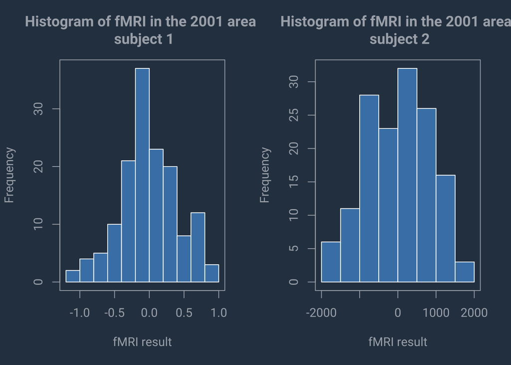

```r
sub_1 <- td_sel$caltech_0051487$`2001`
sub_2 <- td_sel$trinity_0050259$`2001`
par(mfrow = c( 1, 2 ))
hist(sub_1 , main = "Histogram of fMRI in the 2001 area \n subject 1",
     col = "#4682b4", border = "white" , freq = T , xlab = "fMRI result"

)

box()

hist(sub_2 , main = "Histogram of fMRI in the 2001 area \n subject 2",
     col= "#4682b4", border = "white" , freq = T , xlab = "fMRI result"
)

box()
```

To remove the subject-specific effect we subtract the 116 time series arithmetic meansand divide by their corresponding across time standard deviations.

```r
scale_datasets_list <- function(ls){
  scaled_list <- list()
  names <- names(ls)
  for(i in 1:length(ls)){

    #### Scaling by column.
    patient <- data.frame(apply(ls[[i]], 2, scale))
    colnames(patient) <- colnames(ls[[i]])
    scaled_list[[names[i]]] <-patient
  }
  return(scaled_list)
}

td_sel_scale <- scale_datasets_list(td_sel)
asd_sel_scale <- scale_datasets_list(asd_sel)
```

## Pool Together

To achieve the goal of enhance the separation between ASD and TD subjects, we pool the data within each group, by taking a statistical summary across subject on a per-time and per ROI data. To be more robust on the analysis we take the median as the statisical summary.

We assumed within group double independence (across time and subjects), we will not consider the time dependency and so we treat the data as $i.i.d.$.

```r
#### Mean by cell given list of datasets
cells_value_array <- function(ls, i, j){
  cells_value <- c()
  for(patient in ls){
    cells_value <- c(cells_value, patient[i,j])
  }
  return(cells_value)
}


#### Choose metric =c('mean', 'median', 'sd')
summary_dataset <- function(ls, metric='mean'){
  if(metric=='mean'){fun <- mean}
  if(metric=='median'){fun <- median}
  if(metric=='sd'){fun <- sd}

  n <- nrow(ls[[1]])
  m <- ncol(ls[[1]])
  mean_data <- matrix(rep(NA,n*m), n, m)
  for(i in 1:n){
    for(j in 1:m){
      mean_data[i,j] <- fun(cells_value_array(ls, i, j))
    }
  }
  data_frame <-data.frame(mean_data)
  colnames(data_frame) <- colnames(ls[[1]])
  return(data_frame)
}


TD <- summary_dataset(td_sel_scale, metric='median')
ASD <- summary_dataset(asd_sel_scale, metric='median')
```

As a consequence of this approach we end up with two $116 \times 116$ matrices,rappresent the correlations between all the cortical region for the two groups.

Correlations might be used to examine the relationship between brain fMRI data. By calculating correlations between these regions, we can determine whether there is a relationship and how strong it is.It is a way of understanding how different regions of the brain are connected and how they influence each other’s activity. If two brain regions consistently show strong positive correlations, it means that their activity tends to increase or decrease together, it might suggest that they are strongly connected and influence each other’s activity.

First we can have a look at the empirical distribution of the Pearson correlation coefficients within the groups.The distribution of correlations can provide insights into brain function and can be helpful to understand how different brain regions contribute to various cognitive processes.

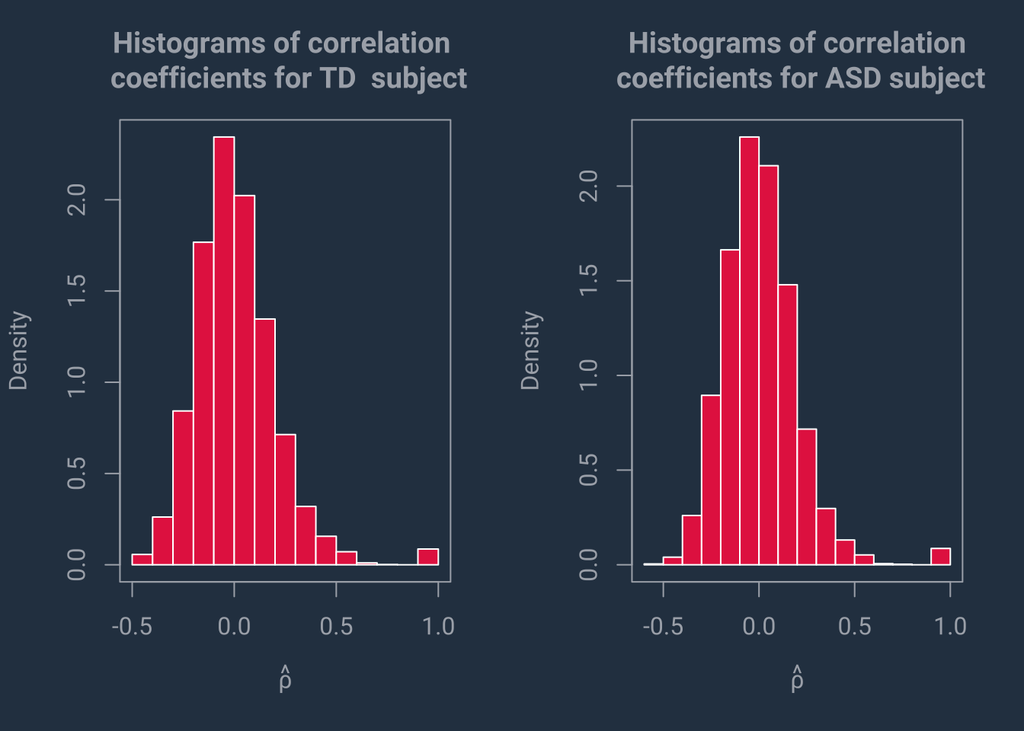

```r
par(mfrow = c( 1 ,2 ))

hist(cor(TD) ,
     main = "Histograms of correlation \n coefficients for TD  subject",
     xlab = expression(hat(rho)) ,
     border = "white" ,
     col = "#E52B50"  , freq = FALSE )
box()

hist(cor(ASD) ,
     main = "Histograms of correlation\n coefficients for ASD subject",
     xlab = expression(hat(rho)) ,
     border = "white" ,
     col = "#E52B50", freq = FALSE )
box()
```

For evaluating dependency between cortical regions we have been used the association graph.

For each pair {j,k} of cortical regions we tested at confidence level setted to $\alpha = 0.05$if they are uncorelleated:

$$\begin{cases}
H_{0} :\hat{\rho_{j,k}} = 0 \\
H_{1} :\hat{\rho_{j,k}} \neq 0\\
\end{cases}$$

To test so, we compute for each pair {j,k} the confidence intervals, rejecting the null Hypothesis if the intervals does not intersect with the value 0.

Generically, having a threshold t , we can require a as we like strong correlation between the ares.

### Process to compute the Confidence intervals

To compute confidence intervals for a family of correlation coefficients, we used the Fisher’s Z transformation. This method involves converting the correlation coefficients to a new scale called z-scores.

$$\hat z_{j,k} =
\frac{1}{2}log\big(\frac{1 + \hat\rho_{j,k}}{1 - \hat\rho_{j,k}}\big) =
artanh(\hat\rho)$$

where it is asymptotically normally distributed as a gaussian with mean $z_{j,k}$ and standard error $\frac{1}{\sqrt{N-3}}$

Once converted the correlations coefficients to z-scores, we can use the normal distribution to build confidence intervals, and then convert lower and upper bound back to the original scale by using the inverse of z-transformation.

Since we are dealing with family wise test, in order to control the probability of making at least one error we can adjust the $\alpha$ confidence level by using Bonferroni Correction. The confidence level would be divided by the number of correlations coefficient we are testing $\binom{D}{2} = \frac{116 \times 115}{2} = 6.670$.

```r
lower_or_upper <- function(data, bound, cor_type='normal', bonferroni=TRUE){

  #### Setting Parameters
  n <- dim(data)[1]
  D <- dim(data)[2]
  alpha <- .05
  m <- choose(D, 2)   # Binomial coefficient

  #### Bonferroni Correction
  if(bonferroni == TRUE){ alpha <- alpha / m }


  #### Use "Correlation" or "Partial Correlation"
  if(cor_type == 'normal'){
    g <- 0
    corr_matrix <- cor(data) }
  if(cor_type == 'partial'){
    g <- D-2
    corr_matrix <- pcor(data) }

  #### Computing Fisher Z-Transform
  Z_j_k_td <- (1/2)*log((1+corr_matrix)/(1-corr_matrix))

  #### Confidence intervals for theta
  se <- sqrt(1/( n - g - 3))
  Log_lower <- Z_j_k_td - qnorm(1 - (alpha/2)) * se
  Log_upper <- Z_j_k_td + qnorm(1 - (alpha/2)) * se

  #### Confidence intervals for rho
  Lower_bound <- (exp(2*Log_lower) - 1 ) /   ((exp(2*Log_lower) + 1))
  Upper_bound <- (exp(2*Log_upper) - 1 ) /   ((exp(2*Log_upper) + 1))

  #### Remove NA (on diagonal)
  Lower_bound[is.na(Lower_bound)] = 1
  Upper_bound[is.na(Upper_bound)] = 1

  if(bound == 'L'){ return(Lower_bound) }
  if(bound == 'U'){ return(Upper_bound) }
}
```

By increasing the value of the threshold t we basically require a strongest correlation between the two regions.

We set the adjacency matrix as a (D x D) matrix where there is 1 if for the pair {j , k} the null hypothesis is rejected and 0 otherwise.

```r
adj_matrix_func <- function(mat , t , bonf = TRUE){
  L <-  lower_or_upper(mat , "L", bonferroni = bonf)
  U <-  lower_or_upper(mat , "U", bonferroni = bonf )
  adj <- as.matrix(L > t | U < -t)
  return(adj)
}
```

The graph is represented by G = (V, E) where V = {V1, . . . , VD} is the vertex–set and E the edge–set.The edge–set E is as a (D × D) adjacency matrix E where E(j, k) = 1 if there is an edge between regions j and regions k and 0 otherwise.

After all we can visualize the association graph f0r the two groups slicing the value of threshold t in order to see co-activation differences.

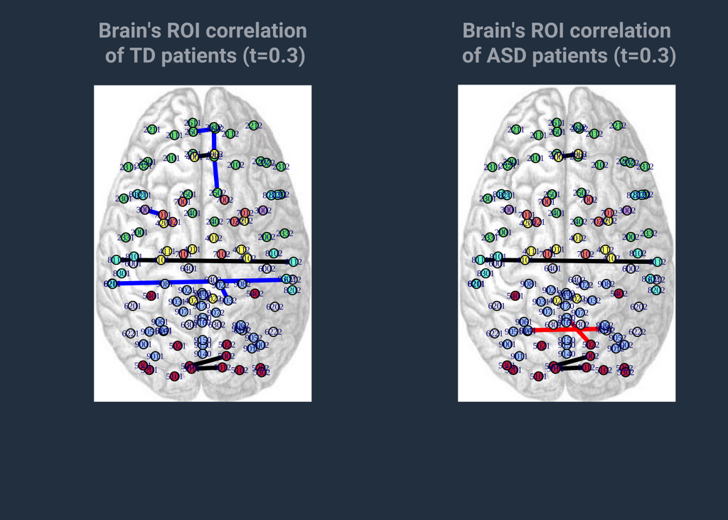

```r
plot_graphs <- function(mat_1 , mat_2 ,t, dimensions=2 , bonferroni = TRUE){

  adj_mat_1 <- adj_matrix_func(mat_1, t = t, bonferroni)
  adj_mat_2 <- adj_matrix_func(mat_2, t = t, bonferroni)

  #Check if there are edges
  if(sum(adj_mat_1) == 116 & sum(adj_mat_2)==116){
    return('There are no edges. Try with lower value of t')
  }

  #### Create Graphs
  g1 <- graph.adjacency(adj_mat_1, mode = "undirected", diag = FALSE )
  g2 <- graph.adjacency(adj_mat_2, mode = "undirected", diag = FALSE )


  #### Set nodes colors based on ROIs
  colors <- c('0','#77DD77', '#C8A2C8', '#FFFF66', '#CB3234', '#E1E1E2', '#ff8c69', '#7fffd4', '#ABCDEF')

  for(i in 1:length(V(g1)$name)){
    V(g1)$color[i] <- colors[strtoi(substr(V(g1)$name[i],1,1))]
    V(g2)$color[i] <- colors[strtoi(substr(V(g2)$name[i],1,1))] }


  #### Change edges colors based on if they are present in both graphs or in only one
  for(i in 1:length(E(g1))){
    edge <- as_ids(E(g1)[i])
    if(edge %in% as_ids(E(g2))){E(g1)[i]$color = 'black'}
    else{E(g1)[i]$color = 'blue'} }


  for(i in 1:length(E(g2))){
    edge <- as_ids(E(g2)[i])
    if(edge %in% as_ids(E(g1))){E(g2)[i]$color = 'black'}
    else{E(g2)[i]$color = 'red'} }


  #### Import ROI coordinates
  load('data/coordinates.RData')
  coord <- aal116coordinates

  if(dimensions == 2){
    #### 2D Plot
    par(mfrow=c(1,2))
    layout <- matrix(c(coord$x.mni, coord$y.mni), 116,2)

    my_image <- readJPEG("images/brain.jpg")

    for(graph in list(g1,g2)){

      if(identical_graphs(graph, g1)){main = paste0("Brain's ROI correlation\n of TD patients (t=", t, ')')}
      if(identical_graphs(graph, g2)){main = paste0("Brain's ROI correlation\n of ASD patients (t=", t, ')')}

      plot(0,0, type='n', xlim=c(-1.2, 1.2), ylim=c(-1.2, 1.2), axes=F, main=main, xlab='', ylab='')

      rasterImage(my_image, xleft=-1.2, xright=1.2, ybottom=-1.2, ytop=1.3)

      plot(graph, vertex.size=10, vertex.label.cex=.5, vertex.color=V(graph)$color, vertex.shape='circle',
           edge.width=4, edge.color=E(graph)$color, vertex.label.col = 'black',
           layout=layout, add=T) }}


  if(dimensions == 3){
    #### 3D Plot
    layout <- matrix(c(coord$x.mni, coord$y.mni, coord$z.mni), 116,3)

    for(graph in list(g1, g2)){
      rglplot(graph,
              vertex.size=7, vertex.label.cex=.5, vertex.color=V(graph)$color,
              edge.width=4, edge.color=E(graph)$color,
              layout=layout, main=main) }}
}


plot_graphs(TD, ASD ,t = .3 , dimensions=2)
```

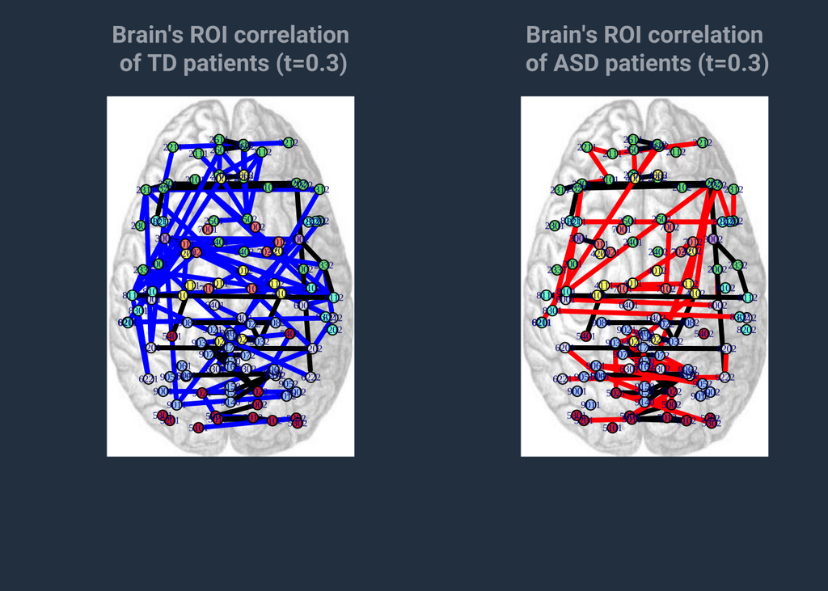

```r
plot_graphs(TD, ASD , t = .3 , dimensions = 2 , bonferroni = FALSE)
```